# Anaerobic CUE

03 Filtering out rare taxa

Roey Angel

2021-02-09

## Filter out rare taxa and those not classified as bacteria or archaea

### Setting general parameters:

```r
set.seed(2021)
prev_thresh <- 0.1 # remove ASVs with prevalence less than that
samples_prep_path <- "./"
data_path <- "./DADA2_pseudo/"
# Metadata_table <- "./AnCUE_Metadata_decontam.csv"
# Seq_table <- "DADA2.seqtab_nochim_decontam.tsv"
# Seq_file <- "DADA2.Seqs_decontam.fa"
Ps_file <- "Ps_obj_decontam.Rds"
Seq_file <- "DADA2.Seqs_decontam.fa"
```

### Read phyloseq object

Also remove controls

```r
readRDS(paste0(data_path, Ps_file)) ->
  Ps_obj

Ps_obj %>%
  subset_samples(., Hours == 0) ->
  Ps_obj_t0

Ps_obj  %>%
  subset_samples(., Hours != 0 & !is.na(Site)) ->
  Ps_obj_SIP
```

Combine repeated runs

```r
sample_data(Ps_obj_SIP) %<>%
  as("data.frame") %>%
  rownames_to_column() %>%
  mutate(Identifier = paste(Site, Oxygen, Glucose, Label..13C., Hours, Fraction.no.,
                            sep = "_")) %>%
  column_to_rownames("rowname")

phyloseq_merge_samples(Ps_obj_SIP, "Identifier") %>%
  filter_taxa(., function(x) sum(x) > 0, TRUE) ->
  Ps_obj_SIP_merged
# Compute lib sizes
sample_data(Ps_obj_SIP_merged)$Lib.size <- rowSums(otu_table(Ps_obj_SIP_merged))
```

### Exploring dataset features

First let’s look at the count data distribution

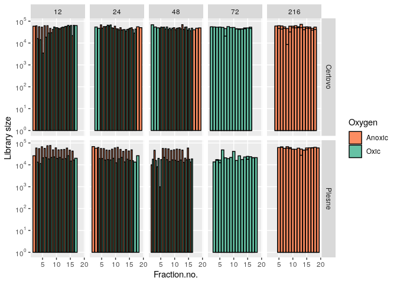

```r
plot_lib_size(Ps_obj_SIP_merged, x = "Fraction.no.", fill = "Oxygen", facet1 = "Site", facet2 = "Hours")
```

I will test now the effect of library size and all other experimental factors on the community composition and also plot

```r
(mod1 <- adonis(vegdist(otu_table(Ps_obj_SIP_merged), method = "bray") ~ Site * Oxygen * Hours + Lib.size,
  data = as(sample_data(Ps_obj_SIP_merged), "data.frame"),
  permutations = 999
))
```

```
##
## Call:
## adonis(formula = vegdist(otu_table(Ps_obj_SIP_merged), method = "bray") ~      Site * Oxygen * Hours + Lib.size, data = as(sample_data(Ps_obj_SIP_merged),      "data.frame"), permutations = 999)
##
## Permutation: free
## Number of permutations: 999
##
## Terms added sequentially (first to last)
##
##                    Df SumsOfSqs MeanSqs F.Model      R2 Pr(>F)
## Site                1    22.555 22.5553 314.924 0.39126  0.001 ***
## Oxygen              1     6.377  6.3767  89.033 0.11061  0.001 ***
## Hours               1     0.333  0.3332   4.652 0.00578  0.002 **
## Lib.size            1     4.943  4.9430  69.016 0.08575  0.001 ***
## Site:Oxygen         1     1.483  1.4830  20.706 0.02573  0.001 ***
## Site:Hours          1     0.471  0.4707   6.572 0.00817  0.002 **
## Oxygen:Hours        1     0.281  0.2809   3.922 0.00487  0.005 **
## Site:Oxygen:Hours   1     0.363  0.3631   5.070 0.00630  0.001 ***
## Residuals         291    20.842  0.0716         0.36154
## Total             299    57.648                 1.00000
## ---
## Signif. codes:  0 '***' 0.001 '**' 0.01 '*' 0.05 '.' 0.1 ' ' 1
```

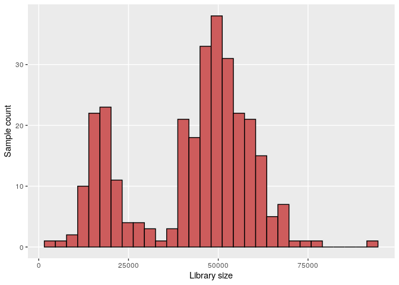

```r
plot_lib_dist(Ps_obj_SIP_merged)
```

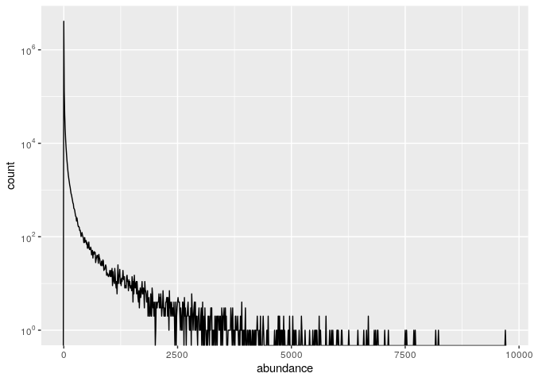

```r
plot_read_dist(Ps_obj_SIP_merged)
```

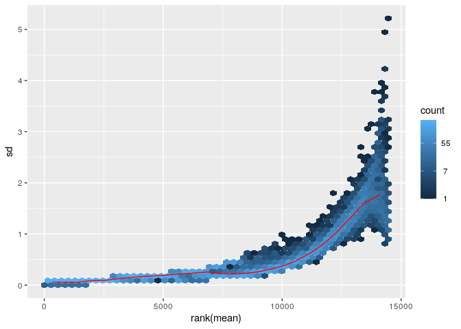

```r
plot_mean_SD(Ps_obj_SIP_merged)
```

Modelling library size shows a significant effect of read depth on the community structure, but explaining only 9% of the variance. The reads histogram shows as expected a highly sparse and skewed sequence matrix. The mean vs SD also shows as expected large dependency of SD on the mean reads of a sequence across all samples.

#### Taxa-based filtering

Frist let’s look at the taxonomic distribution

```r
table(tax_table(Ps_obj_SIP_merged)[, "Kingdom"], exclude = NULL)
```

```
##
##  Archaea Bacteria
##      185    14280
```

```r
table(tax_table(Ps_obj_SIP_merged)[, "Class"], exclude = NULL)
```

```
##
##          Abditibacteria          Acidimicrobiia          Acidobacteriae
##                      21                     679                    1199
##          Actinobacteria                     AD3     Alphaproteobacteria
##                     784                      27                    2031
##            Anaerolineae           Armatimonadia                Babeliae
##                       3                      84                     680
##                 Bacilli             Bacteroidia                  BD7-11
##                     459                     503                      16
##         Bdellovibrionia          Blastocatellia         Campylobacteria
##                     110                      20                       5
##              Chlamydiae            Chloroflexia        Chthonomonadetes
##                     583                       4                      63
##              Clostridia          Coriobacteriia          Cyanobacteriia
##                     276                       4                     178
##         Dehalococcoidia              Deinococci      Desulfitobacteriia
##                       1                      10                      12
##           Desulfobulbia        Desulfovibrionia           Elusimicrobia
##                       1                       2                      14
##            Endomicrobia           Fibrobacteria          Fimbriimonadia
##                       2                       5                      58
##           Fusobacteriia     Gammaproteobacteria        Gemmatimonadetes
##                      21                    2250                      25
##             Gitt-GS-136         Gracilibacteria            Halobacteria
##                       1                       1                       1
##              Holophagae         Hydrogenedentia            JG30-KF-CM66
##                       2                       1                      25
##            Kapabacteria                  KD4-96         Ktedonobacteria
##                      10                       1                      82
##           Lentisphaeria             Lineage IIa           Longimicrobia
##                       2                       5                       2
##         Methanobacteria            Micrarchaeia              Myxococcia
##                       1                       4                     111
##           Negativicutes         Nitrososphaeria             Oligoflexia
##                      13                     129                     106
##                   OM190             Omnitrophia           Parcubacteria
##                       1                      11                      11
##           Phycisphaerae          Planctomycetes               Polyangia
##                     154                    1703                     146
##            Rhodothermia S0134 terrestrial group         Saccharimonadia
##                       2                       1                      49
##       Sericytochromatia                  SJA-28            Spirochaetia
##                       1                       1                       1
##             Subgroup 22              Subgroup 5       Syntrophobacteria
##                       1                      12                       1
##     Thermoanaerobaculia         Thermoleophilia          Thermoplasmata
##                       2                     223                      50
##                    TK10            Unclassified               vadinHA49
##                      10                     615                      11
##        Vampirivibrionia        Verrucomicrobiae        Vicinamibacteria
##                     206                     599                      27
```

```r
# table(tax_table(Ps_obj)[, "Family"], exclude = NULL)
```

Now let’s remove some taxa which are obvious artefacts or those which aren’t bacteria or archaea

```r
kingdoms2remove <- c("", "Eukaryota", "Unclassified")
orders2remove <- c("Chloroplast")
families2remove <- c("Mitochondria")

Ps_obj_kingdoms <- tax_glom(Ps_obj_SIP_merged, "Kingdom")
Ps_obj_orders <- tax_glom(Ps_obj_SIP_merged, "Order")
Ps_obj_families <- tax_glom(Ps_obj_SIP_merged, "Family")

Ps_obj_SIP_merged_filt <- subset_taxa(Ps_obj_SIP_merged, !is.na(Phylum) &
                        !Kingdom %in% kingdoms2remove &
                      !Order %in% orders2remove &
                      !Family %in% families2remove)
```

```r
Summary_pruned <- tibble(
  Level = c("Kingdom", "Order", "Family"),
  ASVs.removed = c(
    table(tax_table(Ps_obj)[, "Kingdom"], exclude = NULL) %>% as.data.frame() %>% .[.$Var1 == "" | .$Var1 == "Eukaryota" | .$Var1 == "Unclassified", 2] %>% sum(),
    table(tax_table(Ps_obj)[, "Order"], exclude = NULL) %>% as.data.frame() %>% .[.$Var1 == "Chloroplast", 2] %>% sum(),
    table(tax_table(Ps_obj)[, "Family"], exclude = NULL) %>% as.data.frame() %>% .[.$Var1 == "Mitochondria", 2] %>% sum()
                     ),
  Seqs.removed = c(
    psmelt(Ps_obj_kingdoms) %>%
      group_by(Kingdom) %>%
      filter(Kingdom == "" |
               Kingdom == "Eukaryota" | Kingdom == "Unclassified") %>%
      summarise(sum = sum(Abundance)) %>% .$sum %>% sum(),
    psmelt(Ps_obj_orders) %>%
      group_by(Order) %>%
      filter(Order == orders2remove) %>%
      summarise(sum = sum(Abundance)) %>% .$sum %>% sum(),
    psmelt(Ps_obj_families) %>%
      group_by(Family) %>%
      filter(Family == families2remove) %>%
      summarise(sum = sum(Abundance)) %>% .$sum %>% sum()
    )
  )
Summary_pruned %>%
  kable(., digits = c(0, 1, 0)) %>%
  kable_styling(bootstrap_options = c("striped", "hover", "condensed", "responsive"), full_width = F)
```

| Level | ASVs.removed | Seqs.removed |
| --- | --- | --- |
| Kingdom | 0 | 0 |
| Order | 136 | 4294 |
| Family | 138 | 15725 |

Now let’s explore the prevalence of different taxa in the database. Prevalence is the number of samples in which a taxa appears at least once. So “Mean prevalence” refers to in how many samples does a sequence belonging to the phylum appears on average, and “Sum prevalence” is the sum of all samples where any sequence from the taxon appears.

```r
prevdf <- apply(X = otu_table(Ps_obj_SIP_merged_filt),
                 MARGIN = ifelse(taxa_are_rows(Ps_obj_SIP_merged_filt), yes = 1, no = 2),
                 FUN = function(x){sum(x > 0)})
# Add taxonomy and total read counts to this data.frame
prevdf <- data.frame(Prevalence = prevdf,
                      TotalAbundance = taxa_sums(Ps_obj_SIP_merged_filt),
                      tax_table(Ps_obj_SIP_merged_filt))

prevdf %>%
  group_by(Phylum) %>%
  summarise(`Mean prevalence` = mean(Prevalence),
            `Sum prevalence` = sum(Prevalence)) ->
  Prevalence_phylum_summary

Prevalence_phylum_summary %>%
  kable(., digits = c(0, 1, 0)) %>%
  kable_styling(bootstrap_options = c("striped", "hover", "condensed", "responsive"), full_width = F)
```

| Phylum | Mean prevalence | Sum prevalence |
| --- | --- | --- |
| Abditibacteriota | 21.3 | 448 |
| Acidobacteriota | 58.2 | 73619 |
| Actinobacteriota | 51.3 | 86754 |
| Armatimonadota | 43.5 | 9178 |
| Bacteroidota | 20.9 | 10783 |
| Bdellovibrionota | 7.5 | 1625 |
| Campilobacterota | 3.6 | 18 |
| Chloroflexi | 29.5 | 4632 |
| Crenarchaeota | 38.9 | 5012 |
| Cyanobacteria | 17.5 | 4458 |
| Deinococcota | 1.5 | 15 |
| Dependentiae | 11.7 | 7981 |
| Desulfobacterota | 6.7 | 40 |
| Elusimicrobiota | 13.0 | 273 |
| Euryarchaeota | 1.0 | 1 |
| FCPU426 | 44.6 | 1606 |
| Fibrobacterota | 9.0 | 45 |
| Firmicutes | 22.1 | 18329 |
| Fusobacteriota | 4.4 | 93 |
| GAL15 | 40.1 | 281 |
| Gemmatimonadota | 16.7 | 468 |
| Halobacterota | 1.0 | 1 |
| Hydrogenedentes | 1.0 | 1 |
| Micrarchaeota | 1.5 | 6 |
| Myxococcota | 46.7 | 11996 |
| Patescibacteria | 9.0 | 588 |
| Planctomycetota | 36.0 | 67790 |
| Proteobacteria | 28.2 | 119347 |
| RCP2-54 | 105.0 | 8924 |
| SAR324 clade(Marine group B) | 33.0 | 33 |
| Spirochaetota | 1.0 | 1 |
| Thermoplasmatota | 49.3 | 2464 |
| Unclassified | 10.3 | 1825 |
| Verrucomicrobiota | 29.7 | 35502 |
| WPS-2 | 63.1 | 8456 |

```r
prevdf %>%
  group_by(Order) %>%
  summarise(`Mean prevalence` = mean(Prevalence),
            `Sum prevalence` = sum(Prevalence)) ->
  Prevalence_order_summary

Prevalence_order_summary %>%
  kable(., digits = c(0, 1, 0)) %>%
  kable_styling(bootstrap_options = c("striped", "hover", "condensed", "responsive"), full_width = F)
```

| Order | Mean prevalence | Sum prevalence |
| --- | --- | --- |
| 0319-6G20 | 8.2 | 655 |
| 11-24 | 7.5 | 15 |
| Abditibacteriales | 21.3 | 448 |
| Absconditabacteriales (SR1) | 2.0 | 2 |
| Acetobacterales | 69.1 | 16435 |
| Acholeplasmatales | 1.0 | 1 |
| Acidaminococcales | 1.0 | 1 |
| Acidimicrobiales | 1.0 | 1 |
| Acidobacteriales | 51.6 | 30887 |
| Actinomycetales | 3.5 | 38 |
| Aeromonadales | 1.0 | 540 |
| Alicyclobacillales | 26.6 | 186 |
| Alteromonadales | 1.0 | 1 |
| Ardenticatenales | 1.0 | 2 |
| Armatimonadales | 43.8 | 3676 |
| Azospirillales | 38.2 | 992 |
| B12-WMSP1 | 1.0 | 1 |
| Babeliales | 11.7 | 7981 |
| Bacillales | 35.0 | 3151 |
| Bacteriovoracales | 1.2 | 5 |
| Bacteroidales | 2.0 | 117 |
| Bacteroidetes VC2.1 Bac22 | 1.5 | 3 |
| Bdellovibrionales | 6.5 | 687 |
| Bifidobacteriales | 1.0 | 3 |
| Blastocatellales | 1.3 | 22 |
| Blfdi19 | 22.5 | 45 |
| Bryobacterales | 76.7 | 11734 |
| Burkholderiales | 23.8 | 6741 |
| Caedibacterales | 11.7 | 82 |
| Caldalkalibacillales | 3.5 | 7 |

[output cut: 149 more lines]

Based on that I’ll remove all orders with a sum prevalence of under 5% (15) of all samples

```r
Prevalence_order_summary %>%
  filter(`Sum prevalence` < (0.05 * nsamples(Ps_obj_SIP_merged_filt))) %>%
  dplyr::select(Order) %>%
  map(as.character) %>%
  unlist() ->
  filterOrder

Ps_obj_SIP_merged_filt2 <- subset_taxa(Ps_obj_SIP_merged_filt, !Order %in% filterOrder)

sample_data(Ps_obj_SIP_merged_filt2)$Lib.size <- rowSums(otu_table(Ps_obj_SIP_merged_filt2))
print(Ps_obj_SIP_merged_filt)
```

```
## phyloseq-class experiment-level object
## otu_table()   OTU Table:          [ 14199 taxa and 300 samples ]:
## sample_data() Sample Data:        [ 300 samples by 29 sample variables ]:
## tax_table()   Taxonomy Table:     [ 14199 taxa by 6 taxonomic ranks ]:
## taxa are columns
```

```r
print(Ps_obj_SIP_merged_filt2)
```

```
## phyloseq-class experiment-level object
## otu_table()   OTU Table:          [ 14099 taxa and 300 samples ]:
## sample_data() Sample Data:        [ 300 samples by 29 sample variables ]:
## tax_table()   Taxonomy Table:     [ 14099 taxa by 6 taxonomic ranks ]:
## taxa are columns
```

This removed 100 or 1% of the ESVs, and 0.046% of the reads.

Plot general prevalence features of the phyla

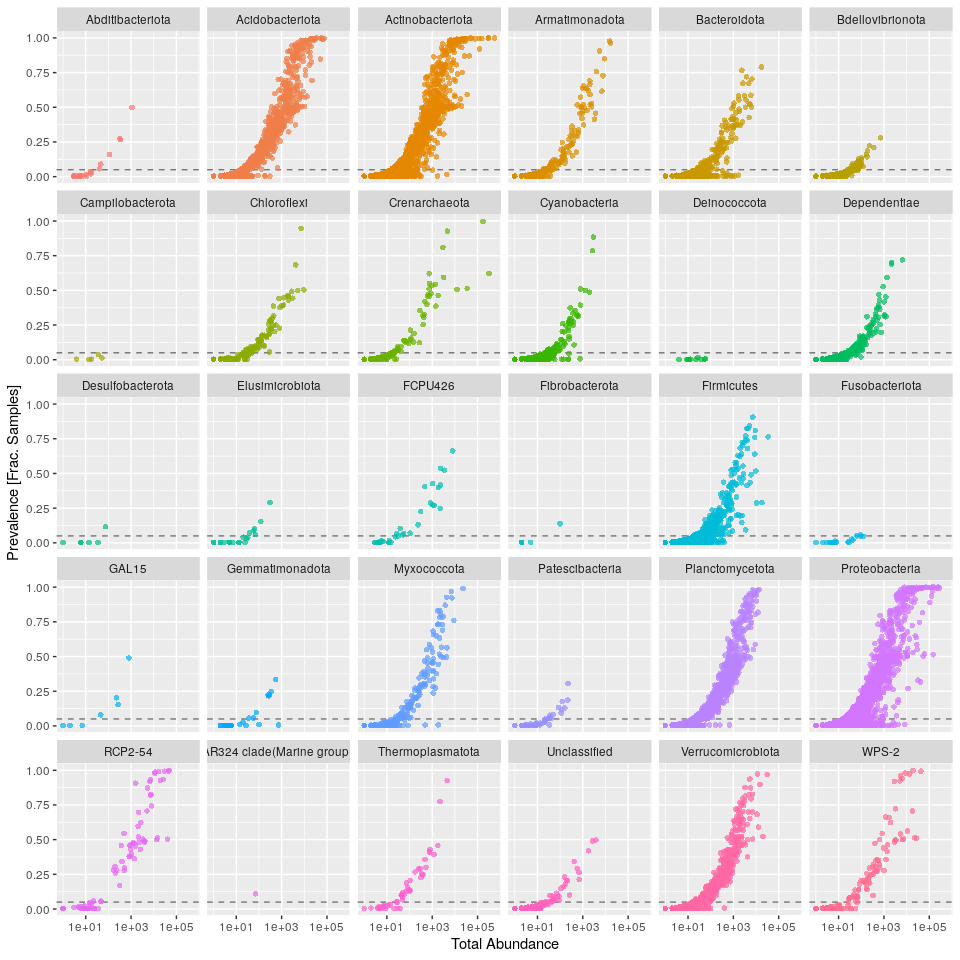

```r
# Subset to the remaining phyla
prevdf_phylum_filt <- subset(prevdf,
                             Phylum %in% get_taxa_unique(Ps_obj_SIP_merged_filt2,
                                                         "Phylum"))
ggplot(prevdf_phylum_filt,
       aes(TotalAbundance,
           Prevalence / nsamples(Ps_obj_SIP_merged_filt2),
           color = Phylum)) +
  # Include a guess for parameter
  geom_hline(yintercept = 0.05,
             alpha = 0.5,
             linetype = 2) +
  geom_point2(size = 2, alpha = 0.7) +
  scale_x_log10() +
  xlab("Total Abundance") +
  ylab("Prevalence [Frac. Samples]") +
  facet_wrap( ~ Phylum) +
  theme(legend.position = "none")
```

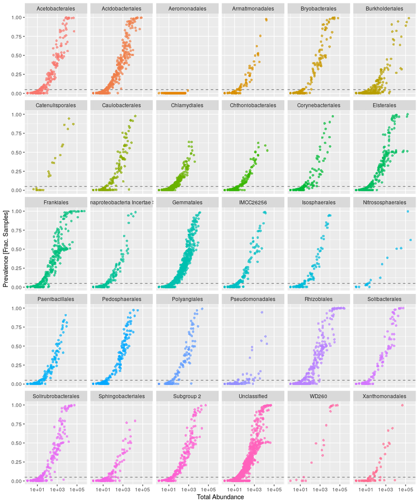

```r
# Subset to the remaining phyla
prevdf_order_filt <- subset(prevdf,
                            Order %in% get_taxa_unique(Ps_obj_SIP_merged_filt2, "Order"))

# grab the top 30 most abundant orders
prevdf_order_filt %>%
  group_by(Order) %>%
  summarise(Combined.abundance = sum(TotalAbundance)) %>%
  arrange(desc(Combined.abundance)) %>%
  .[1:30, "Order"]  ->
  Orders2plot

prevdf_order_filt2 <- subset(prevdf,
                             Order %in% Orders2plot$Order)

ggplot(prevdf_order_filt2,
       aes(TotalAbundance,
           Prevalence / nsamples(Ps_obj_SIP_merged_filt2),
           color = Order)) +
  # Include a guess for parameter
  geom_hline(yintercept = 0.05,
             alpha = 0.5,
             linetype = 2) +
  geom_point2(size = 2, alpha = 0.7) +
  scale_x_log10() +
  xlab("Total Abundance") +
  ylab("Prevalence [Frac. Samples]") +
  facet_wrap( ~ Order) +
  theme(legend.position = "none")
```

#### Unsupervised filtering by prevalence

```r
# Define prevalence threshold as 5% of total samples
prevalenceThreshold <- prev_thresh * nsamples(Ps_obj_SIP_merged_filt2)
prevalenceThreshold
```

```
## [1] 30
```

```r
# Execute prevalence filter, using `prune_taxa()` function
keepTaxa <-
  row.names(prevdf_phylum_filt)[(prevdf_phylum_filt$Prevalence >= prevalenceThreshold)]
Ps_obj_SIP_merged_filt3 <- prune_taxa(keepTaxa, Ps_obj_SIP_merged_filt2)

sample_data(Ps_obj_SIP_merged_filt3)$Lib.size <- rowSums(otu_table(Ps_obj_SIP_merged_filt3))
print(Ps_obj_SIP_merged_filt2)
```

```
## phyloseq-class experiment-level object
## otu_table()   OTU Table:          [ 14099 taxa and 300 samples ]:
## sample_data() Sample Data:        [ 300 samples by 29 sample variables ]:
## tax_table()   Taxonomy Table:     [ 14099 taxa by 6 taxonomic ranks ]:
## taxa are columns
```

```r
print(Ps_obj_SIP_merged_filt3)
```

```
## phyloseq-class experiment-level object
## otu_table()   OTU Table:          [ 3693 taxa and 300 samples ]:
## sample_data() Sample Data:        [ 300 samples by 29 sample variables ]:
## tax_table()   Taxonomy Table:     [ 3693 taxa by 6 taxonomic ranks ]:
## taxa are columns
```

This removed 10406 or 74% of the ESVs!

However all these removed ESVs accounted for only:

```r
prevdf_phylum_filt %>%
  arrange(., Prevalence) %>%
  group_by(Prevalence > prevalenceThreshold) %>%
  summarise(Abundance = sum(TotalAbundance)) %>%
  mutate(`Rel. Ab.` = percent(Abundance / sum(Abundance), accuracy = 0.01)) %>%
  kable(., digits = c(0, 1, 0)) %>%
  kable_styling(bootstrap_options = c("striped", "hover", "condensed", "responsive"), full_width = F)
```

| Prevalence > prevalenceThreshold | Abundance | Rel. Ab. |
| --- | --- | --- |
| FALSE | 303010 | 2.37% |
| TRUE | 12498417 | 97.63% |

So it’s fine to remove them.

Test again the effect of library size and all other experimental factors on the community composition after filtering

```r
(mod1 <- adonis(vegdist(otu_table(Ps_obj_SIP_merged_filt3), method = "bray") ~ Site * Oxygen * Hours + Lib.size,
  data = as(sample_data(Ps_obj_SIP_merged_filt3), "data.frame"),
  permutations = 999
))
```

```
##
## Call:
## adonis(formula = vegdist(otu_table(Ps_obj_SIP_merged_filt3),      method = "bray") ~ Site * Oxygen * Hours + Lib.size, data = as(sample_data(Ps_obj_SIP_merged_filt3),      "data.frame"), permutations = 999)
##
## Permutation: free
## Number of permutations: 999
##
## Terms added sequentially (first to last)
##
##                    Df SumsOfSqs MeanSqs F.Model      R2 Pr(>F)
## Site                1    22.638 22.6379  342.15 0.40294  0.001 ***
## Oxygen              1     6.358  6.3575   96.09 0.11316  0.001 ***
## Hours               1     0.322  0.3223    4.87 0.00574  0.005 **
## Lib.size            1     5.069  5.0686   76.61 0.09022  0.001 ***
## Site:Oxygen         1     1.475  1.4747   22.29 0.02625  0.001 ***
## Site:Hours          1     0.458  0.4576    6.92 0.00814  0.001 ***
## Oxygen:Hours        1     0.264  0.2643    3.99 0.00470  0.007 **
## Site:Oxygen:Hours   1     0.345  0.3448    5.21 0.00614  0.002 **
## Residuals         291    19.254  0.0662         0.34270
## Total             299    56.181                 1.00000
## ---
## Signif. codes:  0 '***' 0.001 '**' 0.01 '*' 0.05 '.' 0.1 ' ' 1
```

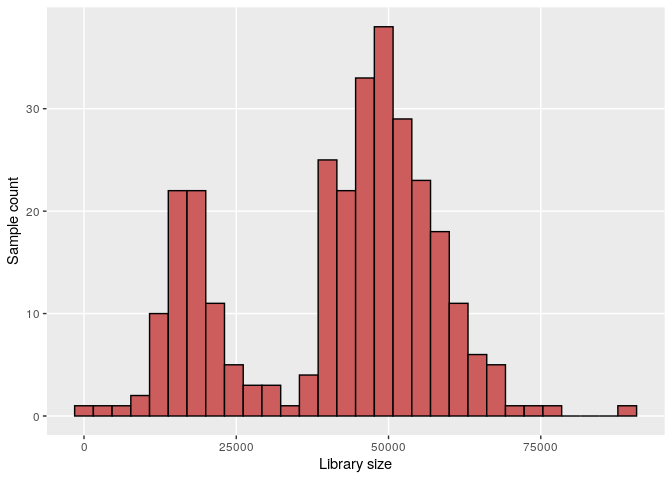

```r
plot_lib_dist(Ps_obj_SIP_merged_filt3)
```

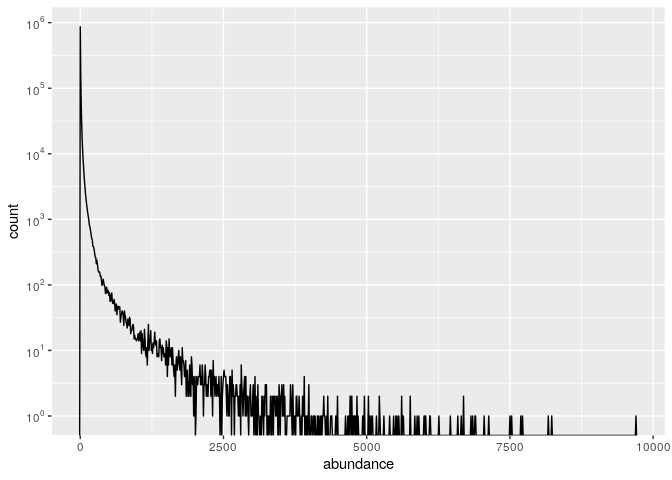

```r
plot_read_dist(Ps_obj_SIP_merged_filt3)
```

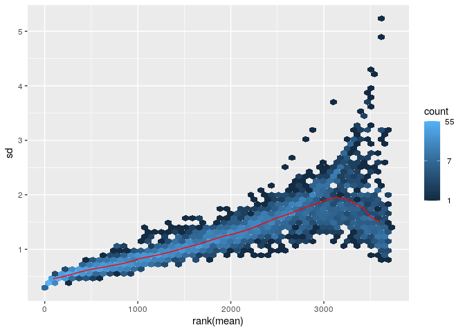

```r
plot_mean_SD(Ps_obj_SIP_merged_filt3)
```

#### Save filtered phyloseq object

```r
saveRDS(Ps_obj_SIP_merged_filt3, file = paste0(data_path, str_remove(Ps_file, ".Rds"), "_filt3.Rds"))
readDNAStringSet(paste0(data_path, Seq_file)) %>%
  .[taxa_names(Ps_obj_SIP_merged_filt3)] %>%
  writeXStringSet(., filepath = paste0(data_path, str_remove(Seq_file, ".fa*"), "_filtered.fa"), format = "fasta", width = 1000)
```

```r
sessioninfo::session_info() %>%
  details::details(
    summary = 'Current session info',
    open    = TRUE
  )
```

**Current session info**

```r
─ Session info ───────────────────────────────────────────────────────────────
 setting  value
 version  R version 4.0.3 (2020-10-10)
 os       Ubuntu 18.04.5 LTS
 system   x86_64, linux-gnu
 ui       X11
 language (EN)
 collate  en_US.UTF-8
 ctype    en_US.UTF-8
 tz       Europe/Prague
 date     2021-02-09

─ Packages ───────────────────────────────────────────────────────────────────
 package        * version    date       lib source
 ade4             1.7-16     2020-10-28 [1] CRAN (R 4.0.2)
 affy             1.66.0     2020-04-27 [1] Bioconductor
 affyio           1.58.0     2020-04-27 [1] Bioconductor
 ape              5.4-1      2020-08-13 [1] CRAN (R 4.0.2)
 assertthat       0.2.1      2019-03-21 [1] CRAN (R 4.0.2)
 backports        1.2.1      2020-12-09 [1] CRAN (R 4.0.2)
 bayestestR       0.8.2      2021-01-26 [1] CRAN (R 4.0.3)
 Biobase        * 2.48.0     2020-04-27 [1] Bioconductor
 BiocGenerics   * 0.34.0     2020-04-27 [1] Bioconductor
 BiocManager      1.30.10    2019-11-16 [1] CRAN (R 4.0.2)
 biomformat       1.16.0     2020-04-27 [1] Bioconductor
 Biostrings     * 2.56.0     2020-04-27 [1] Bioconductor
 broom            0.7.4      2021-01-29 [1] CRAN (R 4.0.3)
 cellranger       1.1.0      2016-07-27 [1] CRAN (R 4.0.2)
 cli              2.3.0      2021-01-31 [1] CRAN (R 4.0.3)
 clipr            0.7.1      2020-10-08 [1] CRAN (R 4.0.2)
 cluster          2.1.0      2019-06-19 [1] CRAN (R 4.0.2)
 codetools        0.2-18     2020-11-04 [1] CRAN (R 4.0.2)
 colorspace       2.0-0      2020-11-11 [1] CRAN (R 4.0.2)
 crayon           1.4.0      2021-01-30 [1] CRAN (R 4.0.3)
 data.table       1.13.6     2020-12-30 [1] CRAN (R 4.0.2)
 DBI              1.1.1      2021-01-15 [1] CRAN (R 4.0.3)
 dbplyr           2.1.0      2021-02-03 [1] CRAN (R 4.0.3)
 desc             1.2.0      2018-05-01 [1] CRAN (R 4.0.2)
 details          0.2.1      2020-01-12 [1] CRAN (R 4.0.2)
 digest           0.6.27     2020-10-24 [1] CRAN (R 4.0.2)
 dplyr          * 1.0.4      2021-02-02 [1] CRAN (R 4.0.3)
 effectsize       0.4.3      2021-01-18 [1] CRAN (R 4.0.3)
 ellipsis         0.3.1      2020-05-15 [1] CRAN (R 4.0.2)
 evaluate         0.14       2019-05-28 [1] CRAN (R 4.0.2)
 extrafont      * 0.17       2014-12-08 [1] CRAN (R 4.0.2)
 extrafontdb      1.0        2012-06-11 [1] CRAN (R 4.0.2)
 farver           2.0.3      2020-01-16 [1] CRAN (R 4.0.2)
 forcats        * 0.5.1      2021-01-27 [1] CRAN (R 4.0.3)
 foreach          1.5.1      2020-10-15 [1] CRAN (R 4.0.2)
 fs               1.5.0      2020-07-31 [1] CRAN (R 4.0.2)
 gdtools          0.2.3      2021-01-06 [1] CRAN (R 4.0.2)
 generics         0.1.0      2020-10-31 [1] CRAN (R 4.0.2)
 ggplot2        * 3.3.3      2020-12-30 [1] CRAN (R 4.0.2)
 ggridges         0.5.3      2021-01-08 [1] CRAN (R 4.0.2)
 glue             1.4.2      2020-08-27 [1] CRAN (R 4.0.2)
 gtable           0.3.0      2019-03-25 [1] CRAN (R 4.0.2)
 haven            2.3.1      2020-06-01 [1] CRAN (R 4.0.2)
 hexbin           1.28.2     2021-01-08 [1] CRAN (R 4.0.2)
 highr            0.8        2019-03-20 [1] CRAN (R 4.0.2)
 hms              1.0.0      2021-01-13 [1] CRAN (R 4.0.3)
 htmltools        0.5.1.1    2021-01-22 [1] CRAN (R 4.0.3)
 httr             1.4.2      2020-07-20 [1] CRAN (R 4.0.2)
 igraph           1.2.6      2020-10-06 [1] CRAN (R 4.0.2)
 insight          0.12.0     2021-01-14 [1] CRAN (R 4.0.3)
 IRanges        * 2.22.2     2020-05-21 [1] Bioconductor
 iterators        1.0.13     2020-10-15 [1] CRAN (R 4.0.2)
 jsonlite         1.7.2      2020-12-09 [1] CRAN (R 4.0.2)
 kableExtra     * 1.3.1      2020-10-22 [1] CRAN (R 4.0.2)
 knitr            1.31       2021-01-27 [1] CRAN (R 4.0.3)
 labeling         0.4.2      2020-10-20 [1] CRAN (R 4.0.2)
 lattice        * 0.20-41    2020-04-02 [1] CRAN (R 4.0.2)
 lifecycle        0.2.0      2020-03-06 [1] CRAN (R 4.0.2)
 limma            3.44.3     2020-06-12 [1] Bioconductor
 lubridate        1.7.9.2    2020-11-13 [1] CRAN (R 4.0.2)
 magrittr       * 2.0.1      2020-11-17 [1] CRAN (R 4.0.2)
 MASS             7.3-53     2020-09-09 [1] CRAN (R 4.0.2)
 Matrix           1.3-2      2021-01-06 [1] CRAN (R 4.0.2)
 mgcv             1.8-33     2020-08-27 [1] CRAN (R 4.0.2)
 modelr           0.1.8      2020-05-19 [1] CRAN (R 4.0.2)
 multtest         2.44.0     2020-04-27 [1] Bioconductor
 munsell          0.5.0      2018-06-12 [1] CRAN (R 4.0.2)
 nlme             3.1-152    2021-02-04 [1] CRAN (R 4.0.3)
 parameters       0.11.0     2021-01-15 [1] CRAN (R 4.0.3)
 permute        * 0.9-5      2019-03-12 [1] CRAN (R 4.0.2)
 phyloseq       * 1.32.0     2020-04-27 [1] Bioconductor
 pillar           1.4.7      2020-11-20 [1] CRAN (R 4.0.2)
 pkgconfig        2.0.3      2019-09-22 [1] CRAN (R 4.0.2)
 plyr             1.8.6      2020-03-03 [1] CRAN (R 4.0.2)
 png              0.1-7      2013-12-03 [1] CRAN (R 4.0.2)
 preprocessCore   1.50.0     2020-04-27 [1] Bioconductor
 prettyunits      1.1.1      2020-01-24 [1] CRAN (R 4.0.2)
 progress         1.2.2      2019-05-16 [1] CRAN (R 4.0.2)
 purrr          * 0.3.4      2020-04-17 [1] CRAN (R 4.0.2)
 R6               2.5.0      2020-10-28 [1] CRAN (R 4.0.2)
 RColorBrewer     1.1-2      2014-12-07 [1] CRAN (R 4.0.2)
 Rcpp             1.0.6      2021-01-15 [1] CRAN (R 4.0.3)
 readr          * 1.4.0      2020-10-05 [1] CRAN (R 4.0.2)
 readxl           1.3.1      2019-03-13 [1] CRAN (R 4.0.2)
 reprex           1.0.0      2021-01-27 [1] CRAN (R 4.0.3)
 reshape2         1.4.4      2020-04-09 [1] CRAN (R 4.0.2)
 rhdf5            2.32.4     2020-10-05 [1] Bioconductor
 Rhdf5lib         1.10.1     2020-07-09 [1] Bioconductor
 rlang            0.4.10     2020-12-30 [1] CRAN (R 4.0.2)
 rmarkdown        2.6        2020-12-14 [1] CRAN (R 4.0.2)
 rprojroot        2.0.2      2020-11-15 [1] CRAN (R 4.0.2)
 rstudioapi       0.13       2020-11-12 [1] CRAN (R 4.0.2)
 Rttf2pt1         1.3.8      2020-01-10 [1] CRAN (R 4.0.2)
 rvest            0.3.6      2020-07-25 [1] CRAN (R 4.0.2)
 S4Vectors      * 0.26.1     2020-05-16 [1] Bioconductor
 scales         * 1.1.1      2020-05-11 [1] CRAN (R 4.0.2)
 see            * 0.6.2      2021-02-04 [1] CRAN (R 4.0.3)
 sessioninfo      1.1.1      2018-11-05 [1] CRAN (R 4.0.2)
 speedyseq      * 0.5.3.9001 2020-10-27 [1] Github (mikemc/speedyseq@8daed32)
 stringi          1.5.3      2020-09-09 [1] CRAN (R 4.0.2)
 stringr        * 1.4.0      2019-02-10 [1] CRAN (R 4.0.2)
 survival         3.2-7      2020-09-28 [1] CRAN (R 4.0.2)
 svglite        * 1.2.3.2    2020-07-07 [1] CRAN (R 4.0.2)
 systemfonts      1.0.0      2021-02-01 [1] CRAN (R 4.0.3)
 tibble         * 3.0.6      2021-01-29 [1] CRAN (R 4.0.3)
 tidyr          * 1.1.2      2020-08-27 [1] CRAN (R 4.0.2)
 tidyselect       1.1.0      2020-05-11 [1] CRAN (R 4.0.2)
 tidyverse      * 1.3.0      2019-11-21 [1] CRAN (R 4.0.2)
 vctrs            0.3.6      2020-12-17 [1] CRAN (R 4.0.2)
 vegan          * 2.5-7      2020-11-28 [1] CRAN (R 4.0.2)
 viridisLite      0.3.0      2018-02-01 [1] CRAN (R 4.0.2)
 vsn            * 3.56.0     2020-04-27 [1] Bioconductor
 webshot          0.5.2      2019-11-22 [1] CRAN (R 4.0.2)
 withr            2.4.1      2021-01-26 [1] CRAN (R 4.0.3)
 xfun             0.20       2021-01-06 [1] CRAN (R 4.0.2)
 xml2             1.3.2      2020-04-23 [1] CRAN (R 4.0.2)
 XVector        * 0.28.0     2020-04-27 [1] Bioconductor
 yaml             2.2.1      2020-02-01 [1] CRAN (R 4.0.2)
 zlibbioc         1.34.0     2020-04-27 [1] Bioconductor

[1] /home/angel/R/library
[2] /usr/local/lib/R/site-library
[3] /usr/lib/R/site-library
[4] /usr/lib/R/library
```